# Module 3- Revealing Knowledge

Blair Wong

2023-02-03

## Background

In this data exploration, I will begin using census tracts rather than neighborhoods to determine which listings are in Boston and its surrounding cities. By using census tracts, I hope to include more data than filtering via a list of neighborhoods, and use it as a means of comparing between census tracts. I will then use the census tract to determine whether the listing is in Boston which will form a new variable, `IN_BOSTON`. `IN_BOSTON` is a simple flag that contains either 0s or 1s to indicate whether the census tract is within the city of Boston.

As mentioned in previous data explorations, I will add a `PRICE_PER_SQ_FT` variable so that prices can be standardized across all listings, rather than trying to compare multi-bedroom apartments with studios.

Finally, I will create a new `LISTING_DATE` variable that combines the `LISTING_YEAR` and `LISTING_MONTH` columns. This will allow for a continuous time series plots rather than plotting each year separately.

From the previous data explorations, I will have filtered out any listings that are considered outliers.

## Methods

#### Filtering Census Tract IDs

In addition to the Craigslist data, I imported data about the census tract IDs in Boston and the surrounding cities. To find the census tract IDs for Boston, I used the census blocks provided by the [Federal Communications Commission](https://www.fcc.gov/general/2020-census-blocks-state). For census tracts in the surrounding cities, I used the [Statistical Atlas](https://statisticalatlas.com/metro-area/Massachusetts/Boston/Overview).

```r
# Import Craigslist Dataset
craigslist_listings<-read.csv('../dataverse_files/CRAIGSLIST.Listings.csv')

# Import Census Tract CSV files
census_tract_boston<-read.csv('../census-tract-data-boston.csv')
census_tract_other<-read.csv('../census-tract-other-cities.csv')
```

In order to work more effectively with the census tracts IDs, I converted the census tract IDs from integers to characters. Then, to filter out the listings outside of Boston and the surrounding cities, I created a list of census tract IDs and filtered the listings based on the IDs in the list. Initially, the lists were separate (Boston and other cities), but were appended into one list for comparison. Afterwards, I filtered out the outliers based on the numbers determined from the previous data exploration.

```r
# Convert Census Tract ID to characters
craigslist_listings$CT_ID_10<-as.character(craigslist_listings$CT_ID_10)
census_tract_other$CENSUS_TRACT_ID<-as.character(census_tract_other$CENSUS_TRACT_ID)
census_tract_boston$GEOCODE<-as.character(census_tract_boston$GEOCODE)

# Create substring column in craigslist_listings and census_tract_boston
craigslist_listings$CT_ID_10_SUB<-substring(craigslist_listings$CT_ID_10,6,11)
census_tract_boston$GEOCODE_SUB<-substring(census_tract_boston$GEOCODE,6,11)

# Create & append lists
census_tract_list_bos<-as.list(census_tract_boston$GEOCODE_SUB)
census_tract_list_other<-as.list(census_tract_other$CENSUS_TRACT_ID)
census_tract_list<-append(census_tract_list_bos, census_tract_list_other)

# Filter by census tract ID's
craigslist_listings_subset<-craigslist_listings %>% filter(CT_ID_10_SUB %in% census_tract_list) %>% select(LISTING_ID,LISTING_YEAR,LISTING_MONTH,LISTING_DAY,LOCATION,AREA_SQFT,PRICE,CT_ID_10_SUB)

# Filter out outliers
craigslist_listings_subset <- filter(craigslist_listings_subset, PRICE > 400)
craigslist_listings_subset <- filter(craigslist_listings_subset, AREA_SQFT < 3000)
craigslist_listings_subset <- filter(craigslist_listings_subset, AREA_SQFT > 500)
```

#### IN_BOSTON

To create the `IN_BOSTON` variable, I added a new column with an `ifelse` statement to indicate whether the census tract ID was in Boston or outside of Boston. To do this, I compared the census tract IDs to the ones listed in Boston’s census tract IDs list and if the census tract ID was in the list, then it was assigned a value of 1 and if it was not, then it was assigned a value of zero.

```r
# Append column for if in Boston
craigslist_listings_subset$IN_BOSTON<-ifelse(craigslist_listings_subset$CT_ID_10_SUB %in% census_tract_list_bos, 1, 0)
```

#### PRICE_PER_SQ_FT

I then added the `PRICE_PER_SQ_FT` variable by first removing the NA values from `AREA_SQFT`, then dividing the `PRICE` by the `AREA_SQFT` and appending it to the dataset.

```r
# Calclulate PRICE_PER_SQ_FT
craigslist_listings_subset<-craigslist_listings_subset %>% drop_na(AREA_SQFT)
craigslist_listings_subset<-craigslist_listings_subset %>% mutate(PRICE_PER_SQ_FT=PRICE/AREA_SQFT)
```

#### LISTING_DATE

Finally, to add the `LISTING_DATE`, I first converted the `LISTING_MONTH` into its numeric representation. Then, I combined the `LISTING_YEAR` and `LISTING_MONTH` into one variable (`LISTING_DATE`). With the new `LISTING_DATE` variable, I then converted it from a string to a date, while also appending “-01” since the `as.Date` function requires a day. The reason for omitting the `LISTING_DAY` variable and appending “-01” instead is so that the data could be shown across equal time intervals.

```r
# Create LISTING_DATE
craigslist_listings_subset$LISTING_MONTH_NUM<-match(craigslist_listings_subset$LISTING_MONTH, month.name)
craigslist_listings_subset<-unite(craigslist_listings_subset, col="LISTING_YR_MONTH", c('LISTING_YEAR', 'LISTING_MONTH_NUM'), sep='-')
craigslist_listings_subset$LISTING_DATE<-as.Date(paste(craigslist_listings_subset$LISTING_YR_MONTH,"-01",sep=""))
```

#### Average Price Per Square Foot Over Time in Two Census Tracts

In order to graph the average price per square foot over time across two census tracts, I first had to calculate the average price per square feet for the listings in each census tract by using the `group_by` function and the `summarise` function.

```r
# Calculating the average price per square ft for each census tract ID
avg_price_per_sq_ft_df<-craigslist_listings_subset %>%
  group_by(CT_ID_10_SUB,LISTING_DATE,IN_BOSTON) %>%
  summarise(AVG_PRICE_PER_SQ_FT = mean(PRICE_PER_SQ_FT))
```

```r
# Filtering by census tract in Cambridge
avg_price_per_sq_ft_df_filtered1<-avg_price_per_sq_ft_df %>% filter(CT_ID_10_SUB=="354100") %>% select(CT_ID_10_SUB,LISTING_DATE,AVG_PRICE_PER_SQ_FT)

# Filtering by census tract in Jamaica Plain
avg_price_per_sq_ft_df_filtered2<-avg_price_per_sq_ft_df %>% filter(CT_ID_10_SUB=="120400") %>% select(CT_ID_10_SUB,LISTING_DATE,AVG_PRICE_PER_SQ_FT)
```

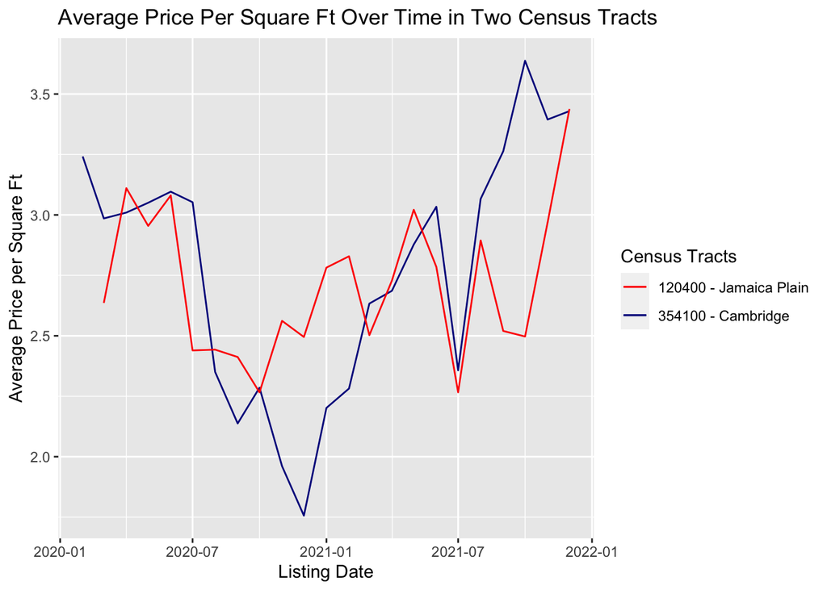

```r
# Creating a time series plot to compare CT in Cambridge and CT in JP
time_series_plot<-ggplot() + geom_line(data=avg_price_per_sq_ft_df_filtered1, aes(x=LISTING_DATE, y=AVG_PRICE_PER_SQ_FT, color="354100 - Cambridge")) + geom_line(data=avg_price_per_sq_ft_df_filtered2, aes(x=LISTING_DATE, y=AVG_PRICE_PER_SQ_FT, color="120400 - Jamaica Plain")) + labs(title="Average Price Per Square Ft Over Time in Two Census Tracts") + xlab("Listing Date") + ylab("Average Price per Square Ft") + scale_color_manual(values = c("354100 - Cambridge" = "darkblue", "120400 - Jamaica Plain" = "red")) + labs(color = "Census Tracts")
time_series_plot
```

#### Average Price Per Square Foot Over Time in Boston vs. Outside of Boston

The process for creating a time series plot for average price per square foot over time in Boston versus outside of Boston was similar. However, instead of averaging the price per square foot over census tract IDs, I averaged it over whether the census tract was within Boston or outside of Boston.

```r
# Calculating average prices for listings in Boston and outside of Boston
avg_price_per_sq_ft_bos<-craigslist_listings_subset %>%
  group_by(IN_BOSTON,LISTING_DATE) %>%
  summarise(AVG_PRICE_PER_SQ_FT = mean(PRICE_PER_SQ_FT))
```

Then, I filtered the new dataset by whether the listings were in Boston or outside of Boston and created a time series plot with dark blue representing listings in Boston and red representing listings outside of Boston.

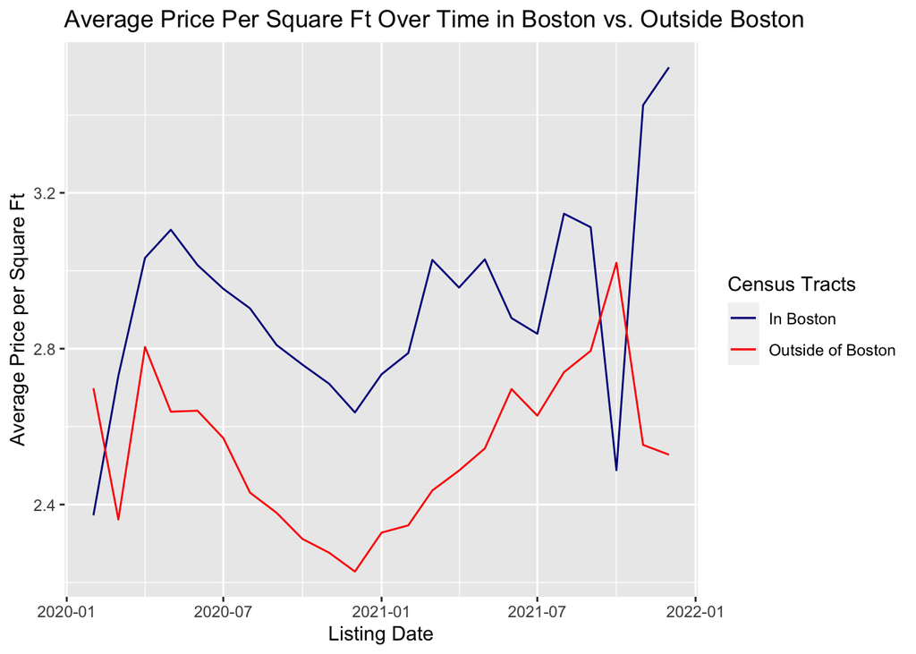

```r
# Filter by CTs in Boston
avg_price_per_sq_ft_df_bos<-avg_price_per_sq_ft_bos %>% filter(IN_BOSTON==1) %>% select(LISTING_DATE,AVG_PRICE_PER_SQ_FT,IN_BOSTON)

# Filter by CTs outside of Boston
avg_price_per_sq_ft_df_other<-avg_price_per_sq_ft_bos %>% filter(IN_BOSTON==0) %>% select(LISTING_DATE,AVG_PRICE_PER_SQ_FT,IN_BOSTON)

# Creating a time series plot to compare in Boston to outside of Boston
time_series_plot_bos<-ggplot() + geom_line(data=avg_price_per_sq_ft_df_bos, aes(x=LISTING_DATE, y=AVG_PRICE_PER_SQ_FT, color="In Boston")) + geom_line(data=avg_price_per_sq_ft_df_other, aes(x=LISTING_DATE, y=AVG_PRICE_PER_SQ_FT, color="Outside of Boston")) + labs(title="Average Price Per Square Ft Over Time in Boston vs. Outside Boston") + xlab("Listing Date") + ylab("Average Price per Square Ft") + scale_color_manual(values = c("In Boston" = "darkblue", "Outside of Boston" = "red")) + labs(color = "Census Tracts")

time_series_plot_bos
```

## Analysis

The three new variables added additional dimensions to the data. With `IN_BOSTON`, we are able to quickly compare and filter based on whether listings were in the city or not. For `PRICE_PER_SQ_FT`, we can now compare across different listing sizes. Lastly, with `LISTING_DATE`, we can analyze the data across multi-year spans.

For the second graph, the Average Price Per Square Foot Over Time in Boston vs. Outside Boston, we can see that there is a significant difference between prices in Boston and prices outside of Boston. It appears as though prices outside of Boston are lower than prices within Boston. Still, both have similar trends with the exception of October 2021 where Boston’s price dips and outside of Boston rises.

In both graphs, there is a dip in average price in the winter of 2021, with the price rising again in the summer of 2021.

## Interpretation & Implications

The two plots show the price diversity across census tracts. We saw that in the inside of Boston vs outside of Boston graph, that there was a significant difference between average price. However, when comparing the census tract in Jamaica Plain with the census tract in Cambridge, we saw that their prices were comparable. This indicates that some cities outside of Boston can be as costly as some of the neighborhoods within Boston. At the same time, the lower prices for the second plot does indicate that as a whole, renting outside of Boston is cheaper than renting in Boston, at least within the 2020 to 2021 period, depending on where someone lives. It is also interesting to see that the different census tracts and whether the listing was in Boston or outside still followed the same general trends. This shows that the market conditions and trends are generally the same across the different census tracts.

With the ability to hone in on and compare between specific census tracts, we can gain a better understanding of the rental costs, as well as other details such as how many listings there are, and whether they allow pets. It’s important to be able to analyze on a census tract level because there can be significant differences between census tracts even within the same neighborhood and understanding the differences allows policymakers and planners to better tailor solutions for specific communities. The ability to filter listings according to whether they’re in Boston or outside of Boston is also important. As the second graph shows, Boston’s rental prices are higher than the surrounding cities, which means that there is still significant work to be done to make housing more affordable in Boston.